# Extrapolating Exascalar

Winston Saunders

November 25, 2014

## Summary

This analysis looks at the extrapolation of current Exascalar trends based on the most recent analysis of the Top500 and Green500 lists.

Code for this analysis is available in the Exascalar [GitHub Repository](https://github.com/ww44ss/Exascalar-Analysis-)

The analysis shows that “Day Zero” for Exascalar, that date when Exascalar of the Top System is expected to be equal to zero, is now in early 2020. The date has pushed out from 2019 primarily because the Top system has not changed for the last two years.

Interestingly, the population median and TopGreen system show following as similar improvement trend, suggesting a strong correlation between the median and computing efficiency improvement.

## Plot and Extrapolation of Exascalar Trends

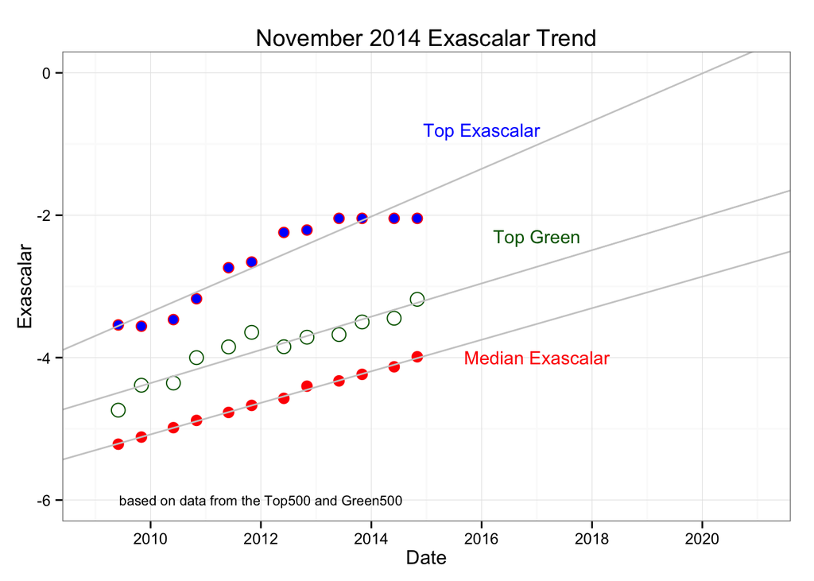

At the current trend the Exascalar “Day zero” is now projected to be 2020-01-07, a somewhat fictitious date when Exscalar will cross the “Zero Line.” Note that this data has been pushing out recently as the Exascalar for the top supercomputer has not changed in the last two years. It shoudl be noted that the Top Exascalar and the Top Performance systems are for the most part identical (the only exceptions being several years ago).

At “Day zero” the Median Exascalar, assuming it follows the current trend, will be -2.86 and the Exascalar of the Top Green supercomputer will be -2.02, again assuming the current trend is followed.

Interestingly the slope of the TopGreen Exascalar line 0.233 parts per per year, with a standard error of 0.026 is close to the slope of the median 0.222 with standard error of 0.004, the difference 0.012 having a t-statistic of 0.4486.

If we were to propose a hypothesis that the slopes of the median and TopGreen lines were different (with a null hypothesis that the slopes are the same) we would not reject the null hypothesis.

## Deeper look at the lists

#### Top Exascalar

This is the list of computers comprising the Top Exascalar list. Note that the Top Performance system corresponds to the top Exascalar system is almost all cases.

```
##        date ExaRank green500rank top500rank exascalar     rmax mflopswatt
##  2009-06-01       1            4          1    -3.541  1105000   444.9400
##  2009-11-01       1            6          2    -3.559  1042000   444.2500
##  2010-06-01       1            4          2    -3.466  1271000   492.6400
##  2010-11-01       1           11          1    -3.173  2566000   635.1500
##  2011-06-01       1            6          1    -2.737  8162000   824.5644
##  2011-11-01       1           32          1    -2.657 10510000   830.1800
##  2012-06-01       1           20          1    -2.242 16324751  2069.0432
##  2012-11-01       1            3          1    -2.208 17590000  2142.7701
##  2013-06-01       1           32          1    -2.044 33862700  1901.5442
##  2013-11-01       1           40          1    -2.044 33862700  1901.5442
##  2014-06-01       1           49          1    -2.044 33862700  1901.5400
##  2014-11-01       1           64          1    -2.044 33862700  1901.5442
```

#### Top Green

The Top Green system list shows some interesting behavior. As you’d expect, since the power of the most efficient system is independent of its efficiency, the performance shows high variablity.

```
##        date ExaRank green500rank top500rank exascalar   rmax mflopswatt
##  2009-06-01      50            1        422    -4.738  18570    536.240
##  2009-11-01      23            1        110    -4.388  43010    722.980
##  2010-06-01      26            1        131    -4.357  44500    773.380
##  2010-11-01      15            1        115    -4.000  65347   1684.200
##  2011-06-01      15            1        109    -3.849  85880   2097.192
##  2011-11-01      15            1         64    -3.645 172494   2026.480
##  2012-06-01      57            1        252    -3.847  86346   2100.876
##  2012-11-01      63            1        251    -3.713 112200   2499.443
##  2013-06-01      65            1        467    -3.676  98511   3208.827
##  2013-11-01      57            1        311    -3.499 125100   4503.181
##  2014-06-01      61            1        437    -3.447 151800   4389.820
##  2014-11-01      34            1        168    -3.181 301300   5271.814
```

This variablity is shown in the plot below of the Exascalar Rank and the Top500 (Performance) rank of the Top Green systems. While a correlation is evident, what is surprising is that the popluation appears to be bimodal, with two apparent populations. Note also that while performance rank range across a wide range, the range of exascalar is much narrower. This is expected. Since Exascalar combines efficiency and performance, higher efficiency systems are favored over lower efficiency systems with equivalent performance, hence accounting for better Exascalar rank.

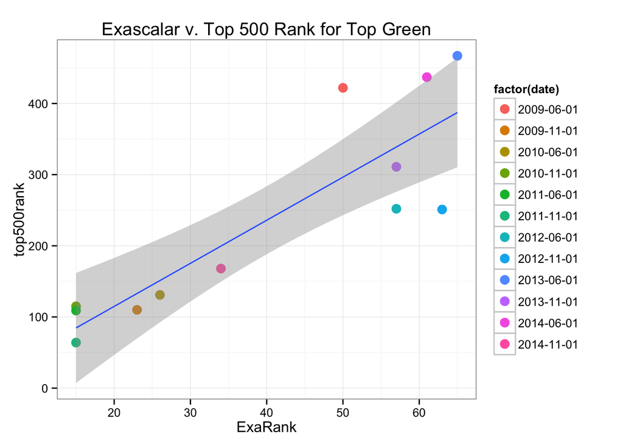

A plot of the Top Green (Highest efficiency) systems for the last several years. While no trend with date is apparent, the correlation of Exascalar ranking and Top500 ranking is as expected.

#### Median Systems

This is the list of “Median” systems (those with Exascalar rank of 250). Note that, as expected, the performance (rmax) and efficiency (mflopswatt) are somewhat erratic. Nevertheless, the median trend of exascalar is consistent. Recall from above the standard error of the fitted line 0.004 is small compared to the slope 0.222.

```
##        date ExaRank green500rank top500rank exascalar      rmax mflopswatt
##  2009-06-01     250          311        136    -5.216  32231.00    65.2600
##  2009-11-01     250          191        347    -5.116  24670.00   118.0400
##  2010-06-01     250          255        168    -4.984  39128.30   114.3500
##  2010-11-01     250          445         54    -4.882 122400.00    51.0000
##  2011-06-01     250          132        470    -4.770  41312.70   217.2980
##  2011-11-01     250          289        240    -4.671  69987.03   177.0200
##  2012-06-01     250          268        220    -4.572  92234.00   185.7684
##  2012-11-01     250          197        261    -4.401 109906.00   271.2858
##  2013-06-01     250          397        119    -4.327 251800.00   150.7081
##  2013-11-01     250          257        202    -4.235 197801.00   259.1732
##  2014-06-01     250          233        272    -4.129 190900.00   378.7700
##  2014-11-01     250          201        426    -3.988 163669.00   700.3980
```